# R Notebook

Loading the data:

```r
library("readxl")
library("class")
library("rjson")
library(MASS)
library(nnet)
library(caret)
library(MLmetrics)
x_raw <- read_excel("./kcmillersean-billboard-hot-100-1958-2017/original/Hot 100 Audio Features.xlsx")
sum(is.na(x_raw$spotify_track_explicit))
```

```
[1] 4749
```

```r
x_raw
```

| SongID | Performer | Song | spotify_genre | spotify_track_id | spotify_track_preview_url | spotify_track_album | spotify_track_explicit | spotify_track_duration_ms | spotify_track_popularity | danceability | energy | key | loudness | mode | speechiness | acousticness | instrumentalness | liveness | valence | tempo | time_signature |
| --- | --- | --- | --- | --- | --- | --- | --- | --- | --- | --- | --- | --- | --- | --- | --- | --- | --- | --- | --- | --- | --- |
| AdictoTainy, Anuel AA & Ozuna | Tainy, Anuel AA & Ozuna | Adicto | ['pop reggaeton'] | 3jbT1Y5MoPwEIpZndDDwVq | NA | Adicto (with Anuel AA & Ozuna) | FALSE | 270740 | 91 | 0.734 | 0.8360 | 10 | -4.803 | 0 | 0.0735 | 1.70e-02 | 1.64e-05 | 0.1790 | 0.6230 | 80.00 | 4 |
| The Ones That Didn't Make It Back HomeJustin Moore | Justin Moore | The Ones That Didn't Make It Back Home | ['arkansas country', 'contemporary country', 'country', 'country road', 'modern country rock', 'redneck'] | NA | NA | NA | NA | NA | NA | NA | NA | NA | NA | NA | NA | NA | NA | NA | NA | NA | NA |
| ShallowLady Gaga & Bradley Cooper | Lady Gaga & Bradley Cooper | Shallow | ['dance pop', 'pop'] | 2VxeLyX666F8uXCJ0dZF8B | NA | A Star Is Born Soundtrack | FALSE | 215733 | 88 | 0.572 | 0.3850 | 7 | -6.362 | 1 | 0.0308 | 3.71e-01 | 0.00e+00 | 0.2310 | 0.3230 | 95.80 | 4 |
| EnemiesPost Malone Featuring DaBaby | Post Malone Featuring DaBaby | Enemies | ['dfw rap', 'melodic rap', 'rap'] | 0Xek5rqai2jcOWCYWJfVCF | NA | Hollywood's Bleeding | TRUE | 196760 | 86 | 0.542 | 0.6740 | 6 | -4.169 | 1 | 0.2100 | 5.88e-02 | 0.00e+00 | 0.0955 | 0.6670 | 76.39 | 4 |
| Bacc At It AgainYella Beezy, Gucci Mane & Quavo | Yella Beezy, Gucci Mane & Quavo | Bacc At It Again | ['dfw rap', 'rap', 'southern hip hop', 'trap'] | 2biNa12dMbHJrHVFRt8JyO | https://p.scdn.co/mp3-preview/fa6fa6f6f363be29ae45af3470675ef5cbcd081f?cid=b8d3901151d34489a160e3cf0ab1fa94 | Bacc At It Again | TRUE | 228185 | 61 | 0.948 | 0.6230 | 8 | -5.725 | 0 | 0.1680 | 1.24e-03 | 1.07e-06 | 0.0716 | 0.8560 | 135.98 | 4 |
| The ArcherTaylor Swift | Taylor Swift | The Archer | ['dance pop', 'pop', 'post-teen pop'] | 3pHkh7d0lzM2AldUtz2x37 | NA | Lover | FALSE | 211240 | 76 | 0.292 | 0.5740 | 0 | -9.375 | 1 | 0.0401 | 1.20e-01 | 5.69e-03 | 0.0663 | 0.1660 | 124.34 | 4 |
| VIBEZDaBaby | DaBaby | VIBEZ | ['nc hip hop', 'rap'] | 0fySG6A6qLE8IvDpayb5bM | NA | KIRK | TRUE | 144935 | 88 | 0.768 | 0.6520 | 1 | -2.708 | 0 | 0.3070 | 1.13e-01 | 0.00e+00 | 0.1070 | 0.7770 | 154.19 | 4 |
| When I Grow UpNF | NF | When I Grow Up | ['hip hop', 'pop rap', 'rap'] | 0hWzB4dR1zwcokPvccww0k | NA | When I Grow Up | FALSE | 196800 | 74 | 0.817 | 0.8140 | 2 | -3.985 | 1 | 0.1850 | 3.20e-01 | 0.00e+00 | 0.1520 | 0.2470 | 109.99 | 4 |
| Hollywood's BleedingPost Malone | Post Malone | Hollywood's Bleeding | ['dfw rap', 'melodic rap', 'rap'] | 7sWRlDoTDX8geTR8zzr2vt | NA | Hollywood's Bleeding | FALSE | 156266 | 85 | 0.405 | 0.6460 | 4 | -3.206 | 0 | 0.0476 | 3.31e-01 | 0.00e+00 | 0.1030 | 0.1700 | 130.22 | 4 |
| What Happens In A Small TownBrantley Gilbert + Lindsay Ell | Brantley Gilbert + Lindsay Ell | What Happens In A Small Town | NA | 44UTzjhEM825Sw0qC89oGK | NA | Fire & Brimstone | FALSE | 203560 | 57 | 0.498 | 0.7880 | 11 | -5.361 | 1 | 0.0402 | 9.34e-04 | 0.00e+00 | 0.1300 | 0.4570 | 138.17 | 4 |

[output cut: 990 more lines]

We eliminate the rows where the target variable is missing.

```r
billboard <- read.csv("./kcmillersean-billboard-hot-100-1958-2017/original/Hot Stuff.csv",header = TRUE)
billboard
```

| url | WeekID | Week.Position | Song | Performer | SongID | Instance | Previous.Week.Position | Peak.Position | Weeks.on.Chart |
| --- | --- | --- | --- | --- | --- | --- | --- | --- | --- |
| http://www.billboard.com/charts/hot-100/1958-08-02 | 8/2/1958 | 1 | Poor Little Fool | Ricky Nelson | Poor Little FoolRicky Nelson | 1 | NA | 1 | 1 |
| http://www.billboard.com/charts/hot-100/1995-12-02 | 12/2/1995 | 1 | One Sweet Day | Mariah Carey & Boyz II Men | One Sweet DayMariah Carey & Boyz II Men | 1 | NA | 1 | 1 |
| http://www.billboard.com/charts/hot-100/1997-10-11 | 10/11/1997 | 1 | Candle In The Wind 1997/Something About The Way You Look Tonight | Elton John | Candle In The Wind 1997/Something About The Way You Look TonightElton John | 1 | NA | 1 | 1 |
| http://www.billboard.com/charts/hot-100/2006-07-01 | 7/1/2006 | 1 | Do I Make You Proud | Taylor Hicks | Do I Make You ProudTaylor Hicks | 1 | NA | 1 | 1 |
| http://www.billboard.com/charts/hot-100/2009-10-24 | 10/24/2009 | 1 | 3 | Britney Spears | 3Britney Spears | 1 | NA | 1 | 1 |
| http://www.billboard.com/charts/hot-100/2011-02-26 | 2/26/2011 | 1 | Born This Way | Lady Gaga | Born This WayLady Gaga | 1 | NA | 1 | 1 |
| http://www.billboard.com/charts/hot-100/2012-03-03 | 3/3/2012 | 1 | Part Of Me | Katy Perry | Part Of MeKaty Perry | 1 | NA | 1 | 1 |
| http://www.billboard.com/charts/hot-100/2014-09-06 | 9/6/2014 | 1 | Shake It Off | Taylor Swift | Shake It OffTaylor Swift | 1 | NA | 1 | 1 |
| http://www.billboard.com/charts/hot-100/2016-02-20 | 2/20/2016 | 1 | Pillowtalk | Zayn | PillowtalkZayn | 1 | NA | 1 | 1 |
| http://www.billboard.com/charts/hot-100/2016-05-28 | 5/28/2016 | 1 | Can't Stop The Feeling! | Justin Timberlake | Can't Stop The Feeling!Justin Timberlake | 1 | NA | 1 | 1 |

[output cut: 990 more lines]

We also eliminate the rows where the regression variables are missing.

```r
x_full <- x_raw[!is.na(x_raw$danceability),]
x_full  <- x_full[!is.na(x_full$spotify_track_explicit),]
sum(is.na(x_full$spotify_track_explicit))
```

```
[1] 0
```

```r
x_full
```

| SongID | Performer | Song | spotify_genre | spotify_track_id | spotify_track_preview_url | spotify_track_album | spotify_track_explicit | spotify_track_duration_ms | spotify_track_popularity | danceability | energy | key | loudness | mode | speechiness | acousticness | instrumentalness | liveness | valence | tempo | time_signature |
| --- | --- | --- | --- | --- | --- | --- | --- | --- | --- | --- | --- | --- | --- | --- | --- | --- | --- | --- | --- | --- | --- |
| AdictoTainy, Anuel AA & Ozuna | Tainy, Anuel AA & Ozuna | Adicto | ['pop reggaeton'] | 3jbT1Y5MoPwEIpZndDDwVq | NA | Adicto (with Anuel AA & Ozuna) | FALSE | 270740 | 91 | 0.734 | 0.8360 | 10 | -4.803 | 0 | 0.0735 | 1.70e-02 | 1.64e-05 | 0.1790 | 0.6230 | 80.00 | 4 |
| ShallowLady Gaga & Bradley Cooper | Lady Gaga & Bradley Cooper | Shallow | ['dance pop', 'pop'] | 2VxeLyX666F8uXCJ0dZF8B | NA | A Star Is Born Soundtrack | FALSE | 215733 | 88 | 0.572 | 0.3850 | 7 | -6.362 | 1 | 0.0308 | 3.71e-01 | 0.00e+00 | 0.2310 | 0.3230 | 95.80 | 4 |
| EnemiesPost Malone Featuring DaBaby | Post Malone Featuring DaBaby | Enemies | ['dfw rap', 'melodic rap', 'rap'] | 0Xek5rqai2jcOWCYWJfVCF | NA | Hollywood's Bleeding | TRUE | 196760 | 86 | 0.542 | 0.6740 | 6 | -4.169 | 1 | 0.2100 | 5.88e-02 | 0.00e+00 | 0.0955 | 0.6670 | 76.39 | 4 |
| Bacc At It AgainYella Beezy, Gucci Mane & Quavo | Yella Beezy, Gucci Mane & Quavo | Bacc At It Again | ['dfw rap', 'rap', 'southern hip hop', 'trap'] | 2biNa12dMbHJrHVFRt8JyO | https://p.scdn.co/mp3-preview/fa6fa6f6f363be29ae45af3470675ef5cbcd081f?cid=b8d3901151d34489a160e3cf0ab1fa94 | Bacc At It Again | TRUE | 228185 | 61 | 0.948 | 0.6230 | 8 | -5.725 | 0 | 0.1680 | 1.24e-03 | 1.07e-06 | 0.0716 | 0.8560 | 135.98 | 4 |
| The ArcherTaylor Swift | Taylor Swift | The Archer | ['dance pop', 'pop', 'post-teen pop'] | 3pHkh7d0lzM2AldUtz2x37 | NA | Lover | FALSE | 211240 | 76 | 0.292 | 0.5740 | 0 | -9.375 | 1 | 0.0401 | 1.20e-01 | 5.69e-03 | 0.0663 | 0.1660 | 124.34 | 4 |
| VIBEZDaBaby | DaBaby | VIBEZ | ['nc hip hop', 'rap'] | 0fySG6A6qLE8IvDpayb5bM | NA | KIRK | TRUE | 144935 | 88 | 0.768 | 0.6520 | 1 | -2.708 | 0 | 0.3070 | 1.13e-01 | 0.00e+00 | 0.1070 | 0.7770 | 154.19 | 4 |
| When I Grow UpNF | NF | When I Grow Up | ['hip hop', 'pop rap', 'rap'] | 0hWzB4dR1zwcokPvccww0k | NA | When I Grow Up | FALSE | 196800 | 74 | 0.817 | 0.8140 | 2 | -3.985 | 1 | 0.1850 | 3.20e-01 | 0.00e+00 | 0.1520 | 0.2470 | 109.99 | 4 |
| Hollywood's BleedingPost Malone | Post Malone | Hollywood's Bleeding | ['dfw rap', 'melodic rap', 'rap'] | 7sWRlDoTDX8geTR8zzr2vt | NA | Hollywood's Bleeding | FALSE | 156266 | 85 | 0.405 | 0.6460 | 4 | -3.206 | 0 | 0.0476 | 3.31e-01 | 0.00e+00 | 0.1030 | 0.1700 | 130.22 | 4 |
| What Happens In A Small TownBrantley Gilbert + Lindsay Ell | Brantley Gilbert + Lindsay Ell | What Happens In A Small Town | NA | 44UTzjhEM825Sw0qC89oGK | NA | Fire & Brimstone | FALSE | 203560 | 57 | 0.498 | 0.7880 | 11 | -5.361 | 1 | 0.0402 | 9.34e-04 | 0.00e+00 | 0.1300 | 0.4570 | 138.17 | 4 |
| Famous HoesNLE Choppa | NLE Choppa | Famous Hoes | ['memphis hip hop'] | 35Xf2ABjPzUXKz19akd7Jj | https://p.scdn.co/mp3-preview/00e1999afe6fef5a56246efee24e75db4998ad3f?cid=b8d3901151d34489a160e3cf0ab1fa94 | Famous Hoes | TRUE | 135460 | 80 | 0.732 | 0.6270 | 4 | -5.693 | 0 | 0.1610 | 3.46e-01 | 0.00e+00 | 0.2610 | 0.3320 | 81.48 | 4 |

[output cut: 990 more lines]

Extract target variable and check if there are any NA’s.

```r
explicit <- x_full$spotify_track_explicit
x <- x_full[,c(9:22)]
colnames(x)[1]<-"duration"
colnames(x)[2]<-"popularity"
x
```

| duration | popularity | danceability | energy | key | loudness | mode | speechiness | acousticness | instrumentalness | liveness | valence | tempo | time_signature |
| --- | --- | --- | --- | --- | --- | --- | --- | --- | --- | --- | --- | --- | --- |
| 270740 | 91 | 0.734 | 0.8360 | 10 | -4.803 | 0 | 0.0735 | 1.70e-02 | 1.64e-05 | 0.1790 | 0.6230 | 80.00 | 4 |
| 215733 | 88 | 0.572 | 0.3850 | 7 | -6.362 | 1 | 0.0308 | 3.71e-01 | 0.00e+00 | 0.2310 | 0.3230 | 95.80 | 4 |
| 196760 | 86 | 0.542 | 0.6740 | 6 | -4.169 | 1 | 0.2100 | 5.88e-02 | 0.00e+00 | 0.0955 | 0.6670 | 76.39 | 4 |
| 228185 | 61 | 0.948 | 0.6230 | 8 | -5.725 | 0 | 0.1680 | 1.24e-03 | 1.07e-06 | 0.0716 | 0.8560 | 135.98 | 4 |
| 211240 | 76 | 0.292 | 0.5740 | 0 | -9.375 | 1 | 0.0401 | 1.20e-01 | 5.69e-03 | 0.0663 | 0.1660 | 124.34 | 4 |
| 144935 | 88 | 0.768 | 0.6520 | 1 | -2.708 | 0 | 0.3070 | 1.13e-01 | 0.00e+00 | 0.1070 | 0.7770 | 154.19 | 4 |
| 196800 | 74 | 0.817 | 0.8140 | 2 | -3.985 | 1 | 0.1850 | 3.20e-01 | 0.00e+00 | 0.1520 | 0.2470 | 109.99 | 4 |
| 156266 | 85 | 0.405 | 0.6460 | 4 | -3.206 | 0 | 0.0476 | 3.31e-01 | 0.00e+00 | 0.1030 | 0.1700 | 130.22 | 4 |
| 203560 | 57 | 0.498 | 0.7880 | 11 | -5.361 | 1 | 0.0402 | 9.34e-04 | 0.00e+00 | 0.1300 | 0.4570 | 138.17 | 4 |
| 135460 | 80 | 0.732 | 0.6270 | 4 | -5.693 | 0 | 0.1610 | 3.46e-01 | 0.00e+00 | 0.2610 | 0.3320 | 81.48 | 4 |

[output cut: 990 more lines]

```r
sum(is.na(x))
```

```
[1] 0
```

Delete key and time_signature

```r
x<-x[,-c(5,14)]
```

```r
dim(x)
```

```
[1] 23676    12
```

*Descriptive analysis*

Correlation matrix:

```r
C <-cor(x)
C
```

```
                    duration  popularity danceability      energy    loudness        mode
duration          1.00000000  0.19810914  0.092919922  0.12737492  0.04015836 -0.12642601
popularity        0.19810914  1.00000000  0.174720923  0.17919595  0.34398993 -0.11551799
danceability      0.09291992  0.17472092  1.000000000  0.20443232  0.13271731 -0.15862762
energy            0.12737492  0.17919595  0.204432318  1.00000000  0.68614305 -0.10393873
loudness          0.04015836  0.34398993  0.132717307  0.68614305  1.00000000 -0.07977649
mode             -0.12642601 -0.11551799 -0.158627624 -0.10393873 -0.07977649  1.00000000
speechiness       0.04517899  0.20361594  0.246814282  0.14099577  0.17164055 -0.13329964
acousticness     -0.29805079 -0.30576268 -0.313068841 -0.58750719 -0.40592734  0.14295670
instrumentalness  0.01713666 -0.11852946  0.001627687 -0.00113371 -0.13264902 -0.01120994
liveness         -0.03407297 -0.07149543 -0.129861234  0.11176775  0.04373553  0.01365576
valence          -0.15135401 -0.20884608  0.396338665  0.35604178  0.02298266 -0.01981331
tempo            -0.01634128  0.02430064 -0.151816967  0.16201218  0.09391829  0.02027891
                 speechiness acousticness instrumentalness    liveness     valence        tempo
duration          0.04517899  -0.29805079      0.017136662 -0.03407297 -0.15135401 -0.016341278
popularity        0.20361594  -0.30576268     -0.118529461 -0.07149543 -0.20884608  0.024300644
danceability      0.24681428  -0.31306884      0.001627687 -0.12986123  0.39633867 -0.151816967
energy            0.14099577  -0.58750719     -0.001133710  0.11176775  0.35604178  0.162012181
loudness          0.17164055  -0.40592734     -0.132649016  0.04373553  0.02298266  0.093918294
mode             -0.13329964   0.14295670     -0.011209945  0.01365576 -0.01981331  0.020278909
speechiness       1.00000000  -0.15490191     -0.056999138  0.07969188 -0.02052001  0.056879580
acousticness     -0.15490191   1.00000000      0.026802890  0.04133453 -0.12336474 -0.105035822
instrumentalness -0.05699914   0.02680289      1.000000000 -0.01322480  0.04756945  0.003096994
liveness          0.07969188   0.04133453     -0.013224803  1.00000000  0.02461112  0.019765001
valence          -0.02052001  -0.12336474      0.047569447  0.02461112  1.00000000  0.072930576
tempo             0.05687958  -0.10503582      0.003096994  0.01976500  0.07293058  1.000000000
```

Highly correlated variables:

```r
for(i in 1 : (nrow(C) - 1)) {
  for(j in (i + 1) : ncol(C)) {
    if(abs(C[i, j]) >= 0.5) print(paste0(rownames(C)[i], " - ", colnames(C)[j]))
  }
}
```

```
[1] "energy - loudness"
[1] "energy - acousticness"
```

Mean values for explicit and non-explicit songs:

```r
mu_exp = as.matrix(apply(x[explicit == TRUE,],2,mean))
mu_exp
```

```
                          [,1]
duration          2.328391e+05
popularity        6.139210e+01
danceability      7.203289e-01
energy            6.612681e-01
loudness         -6.365256e+00
mode              5.505618e-01
speechiness       1.937759e-01
acousticness      1.422686e-01
instrumentalness  6.431818e-03
liveness          1.990280e-01
valence           5.030620e-01
tempo             1.205554e+02
```

```r
mu_nexp = as.matrix(apply(x[explicit == FALSE,],2,mean))
mu_nexp
```

```
                          [,1]
duration          2.199564e+05
popularity        3.800659e+01
danceability      5.833845e-01
energy            6.128126e-01
loudness         -8.999381e+00
mode              7.516473e-01
speechiness       5.689042e-02
acousticness      3.148540e-01
instrumentalness  3.653562e-02
liveness          1.918545e-01
valence           6.177490e-01
tempo             1.201533e+02
```

Variance for ecplicit and non-explicit songs

```r
apply(x[explicit == TRUE,],2,var)
```

```
        duration       popularity     danceability           energy         loudness
    2.944018e+09     2.114043e+02     1.944620e-02     2.283673e-02     5.692062e+00
            mode      speechiness     acousticness instrumentalness         liveness
    2.475394e-01     1.632485e-02     3.011615e-02     2.867618e-03     2.262383e-02
         valence            tempo
    4.817320e-02     9.131658e+02
```

```r
apply(x[explicit == FALSE,],2,var)
```

```
        duration       popularity     danceability           energy         loudness
    4.833257e+09     4.689667e+02     2.184157e-02     4.186070e-02     1.319797e+01
            mode      speechiness     acousticness instrumentalness         liveness
    1.866825e-01     3.255749e-03     8.287255e-02     2.087088e-02     2.588822e-02
         valence            tempo
    5.636188e-02     7.683991e+02
```

Number of observations in every class:

```r
sum(explicit == FALSE)
```

```
[1] 21095
```

```r
sum(explicit == TRUE)
```

```
[1] 2581
```

Histograms of some variables of the two classes to see the difference in the distribution:

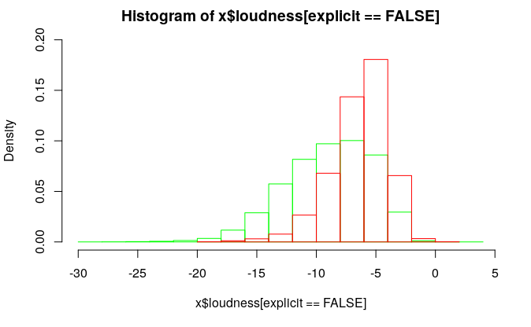

```r
hist(x$loudness[explicit == FALSE],freq = FALSE,border = "green",ylim = c(0,0.2))
hist(x$loudness[explicit == TRUE],freq = FALSE,add  = TRUE,border = "red",ylim = c(0,0.2))
```

```r
NA
NA
```

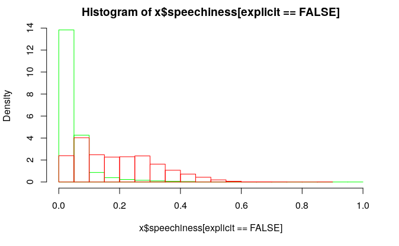

```r
hist(x$speechiness[explicit == FALSE],freq = FALSE,border = "green")
hist(x$speechiness[explicit == TRUE],freq = FALSE,add  = TRUE,border = "red")
```

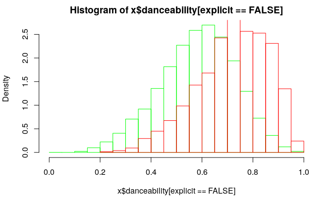

```r
hist(x$danceability[explicit == FALSE],freq = FALSE,border = "green")
hist(x$danceability[explicit == TRUE],freq = FALSE,add  = TRUE,border = "red")
```

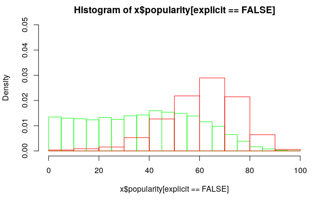

```r
hist(x$popularity[explicit == FALSE],freq = FALSE,border = "green",ylim = c(0,0.05))
hist(x$popularity[explicit == TRUE],freq = FALSE,add  = TRUE,border = "red",ylim = c(0,0.05))
```

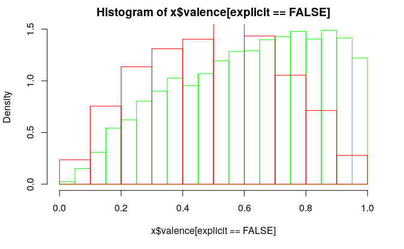

```r
hist(x$valence[explicit == FALSE],freq = FALSE,border = "green")
hist(x$valence[explicit == TRUE],freq = FALSE,add  = TRUE,border = "red")
```

Cluster analysis:

```r
set.seed(123)
xstd = scale(x,scale = TRUE)
c = sample(1:nrow(xstd),1000)
D = dist(xstd[c,])
```

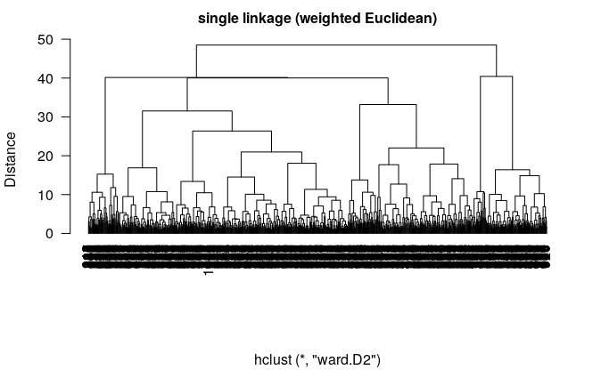

```r
hc.ward <- hclust(D,method="ward.D2")
plot(hc.ward,ylab="Distance",main="single linkage (weighted Euclidean)",
xlab="",hang=-1,las=1,cex.main=1)
```

```r
clusters <- cutree(hc.ward, 2)
table(clusters,explicit[c])
```

```
clusters FALSE TRUE
       1   745   94
       2   161    0
```

LDA to check that the data is separable:

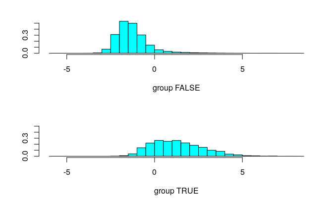

```r
# LDA
library(MASS)
out <- lda(explicit~.,data=x)
plot(out)
```

PCA to check if there is a simple separation:

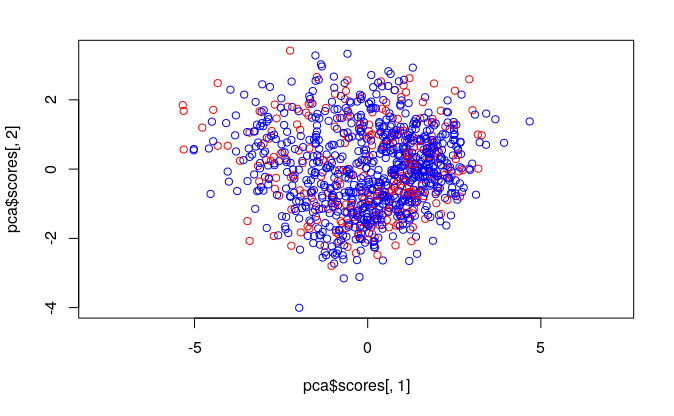

```r
# PCA no separa
pca = princomp(x[c,],cor=TRUE)
plot(pca$scores[,1],pca$scores[,2],col = ifelse(explicit,"red","blue"),asp = 1)
```

## Modeling

```r
g = function(prior,S_inv,mu,x){
  x = t(as.matrix(x))
  g = log(prior) - log((2*pi)^(ncol(S_inv)/2)) -1/2*t(x-mu) %*% S_inv %*% (x-mu)
  return(g)
}

dichotomizer = function(xx,prior_exp,prior_nexp,S_exp_inv,S_nexp_inv,mu_exp,mu_nexp){
    class = rep(0, nrow(xx))
    for (i in 1:nrow(xx)){
        dico = g(prior_exp,S_exp_inv,mu_exp,xx[i,])-g(prior_nexp,S_nexp_inv,mu_nexp,xx[i,])
        if (dico > 0) class[i] = 1
    }
    return(class)
}

F1 = function(y_true,y_pred){
    positives = c(y_true == 1)
    true_positives = sum(positives) - sum((y_true[positives] - y_pred[positives])^2)
    prec = true_positives/sum(y_pred == 1)
    recall = true_positives/sum(y_true == 1)
    F1 = 2*(prec*recall)/(prec+recall)
    return (F1)
}

Error = function(y_true,y_pred,n){
   return(sum((y_true-y_pred)^2)/n)
}
```

We divide the dataset into training and test:

```r
set.seed (4321)
N <- nrow(x)
learn <- sample(1:N, round(0.67*N))
xl = x[learn,]
yl = explicit[learn]
xtest = x[-learn,]
ytest = explicit[-learn]
```

We choose the best k for k-nn with cross-validation. Takes a lot of time to execute, so we keep it commented.

```r
# 88 = round(sqrt(nrow(xtest)))
#c = rep(0,88)
#i=1
#while (i < 88){
#  nn = knn(scale(xl),scale(xtest),as.factor(yl),k=i)
#  sum(nn == "TRUE")
#  c[i] = Error(ytest,as.logical(nn),nrow(xtest))
#  i = i + 2
#  }
#which(c == min(c[c!=0]))
```

The best value for k is k = 11.

```r
errors <- function (model)
{
  options(digits=4)
  p1 <- as.factor(predict (model, type="class"))
  t1 <- table(p1,explicit[learn])
  cat ("Train = ", 100*(1-sum(diag(t1))/length(explicit[learn])),"%\n")
  p2 <- as.factor(predict (model, newdata=xtest, type="class"))
  t2 <- table(p2,explicit[-learn])
  cat ("Test =  ", 100*(1-sum(diag(t2))/length(explicit[-learn])),"%\n")
}
```

Cross validation to check which is the best value for the decay in our NN. Also takes a lot of time so we comment it.

```r
#set.seed(1234)
# model.nnet <- nnet(explicit ~., data = x, entropy = TRUE, softmax = FALSE, linout = FALSE, subset=learn, size=10, maxit=500, decay=0.5)
#x_aux = x
#x_aux$explicit = explicit
#(decays <- 10^seq(-2, 0, by=0.2))
#trc <- trainControl (method="repeatedcv", number=10, repeats=1)
#model.10x10CV <- train (as.factor(explicit) ~ ., data = x_aux, subset=learn, method='nnet',
#                        maxit = 200, trace = FALSE
#                        tuneGrid = expand.grid(.size=20,.decay=decays), trControl=trc)
```

```r
model.10x10CV$results
```

|  | size | decay | Accuracy | Kappa | AccuracySD | KappaSD |
| --- | --- | --- | --- | --- | --- | --- |
| 1 | 20 | 0.01000 | 0.9039 | 0.190086 | 0.0200431 | 0.30622 |
| 2 | 20 | 0.01585 | 0.9080 | 0.255463 | 0.0217582 | 0.33032 |
| 3 | 20 | 0.02512 | 0.8997 | 0.128122 | 0.0173572 | 0.27029 |
| 4 | 20 | 0.03981 | 0.8918 | 0.007691 | 0.0012563 | 0.02432 |
| 5 | 20 | 0.06310 | 0.9036 | 0.188278 | 0.0197137 | 0.30329 |
| 6 | 20 | 0.10000 | 0.9091 | 0.256389 | 0.0228664 | 0.33132 |
| 7 | 20 | 0.15849 | 0.8913 | 0.010123 | 0.0006097 | 0.03201 |
| 8 | 20 | 0.25119 | 0.9085 | 0.252750 | 0.0219471 | 0.32653 |
| 9 | 20 | 0.39811 | 0.9160 | 0.372199 | 0.0213899 | 0.32073 |
| 10 | 20 | 0.63096 | 0.8995 | 0.124786 | 0.0171071 | 0.26309 |

[output cut: 1 more lines]

The best decay is 0.398 ~ 0.4.

# 10-fold Cross Validation for model choosing

```r
library(MLmetrics)
k=10
error = matrix(, nrow = 4, ncol = 10)
f1 = matrix(, nrow = 3, ncol = 10)
fold_size = nrow(xl) %/% k
for (i in 1:k){
    #Definim els talls que definiran els folds
    init = (i-1)*fold_size
    if(i == 10){
    end = nrow(xl)
    }else{
    end = init + fold_size
    }
    xtraining = xl[-c(init:end),]
    ytraining = yl[-c(init:end)]
    xvalidation = xl[c(init:end),]
    yvalidation = yl[c(init:end)]

    #Model0: dichotomizer assuming MVN:
    # Creem el dichotomizer
    # Primer creem les funcions discriminants
    prior_exp = sum(ytraining == TRUE)/nrow(xtraining)
    prior_nexp = 1 - prior_exp
    S_exp = cov(xtraining[ytraining == TRUE,])
    S_nexp = cov(xtraining[ytraining == FALSE,])
    S_exp_inv = solve(S_exp)
    S_nexp_inv = solve(S_nexp)
    prediction0 = dichotomizer(xvalidation,prior_exp,prior_nexp,S_exp_inv,S_nexp_inv,mu_exp,mu_nexp)
    error[1,i] =  Error(as.numeric(yvalidation),prediction0,nrow(xvalidation))
    f1[1,i] = F1_Score(as.numeric(yvalidation),prediction0)

    #Model1: glm with binomial family
    mod1 <- glm(ytraining ~ ., data=as.data.frame(xtraining),family=binomial)
    prediction1 = round(predict(mod1,ty="response",
    newdata = as.data.frame(xvalidation)))
    error[2,i] = Error(as.numeric(yvalidation),prediction1,nrow(xvalidation))
    f1[2,i] = F1_Score(as.numeric(yvalidation),prediction1)

    #Model2: knn
    k_knn = 11 #escollida a fora
    nn = knn(scale(xtraining),scale(xvalidation),as.factor(ytraining),k=k_knn)
    error[3,i] = Error(yvalidation,as.logical(nn),nrow(xvalidation))
    f1[3,i] = F1_Score(as.numeric(yvalidation),as.numeric(as.logical(nn)))

    #Model3: MLP neural network
    set.seed(1234)
    mod3 <- nnet(ytraining ~., data = xtraining, entropy = TRUE, softmax = FALSE, linout = FALSE, trace = FALSE, size=20, maxit=500, decay=0.4)
    options(digits=4)
    pred3 = round(predict(mod3,ty="raw",
    newdata = as.data.frame(xvalidation)))
    error[4,i] = Error(as.numeric(yvalidation),pred3,nrow(xvalidation))
    #f1[4,i] = F1_Score(as.numeric(yvalidation),pred3)
}

error0 = mean(error[1,])
error1 = mean(error[2,])
error2 = mean(error[3,])
error3 = mean(error[4,])
f1_0 = mean(f1[1,])
f1_1 = mean(f1[2,])
f1_2 = mean(f1[3,])
#f1_3 = mean(f1[4,])
error0
```

```
[1] 0.0705
```

```r
error1
```

```
[1] 0.06899
```

```r
error2
```

```
[1] 0.06779
```

```r
error3
```

```
[1] 0.1031
```

```r
print("F1 scores")
```

```
[1] "F1 scores"
```

```r
f1_0
```

```
[1] 0.9606
```

```r
f1_1
```

```
[1] 0.9619
```

```r
f1_2
```

```
[1] 0.9625
```

```r
#f1_3
```

We calculate the error variances.

```r
vars_errors = apply(error,1,var)
var_f1 = apply(f1,1,var)
vars_errors
```

```
[1] 5.519e-05 7.214e-05 3.551e-05 1.593e-04
```

```r
var_f1
```

```
[1] 1.722e-05 2.253e-05 1.154e-05
```

Sembla que el millor és el knn però per molt poc. També és el que té millor variància

```r
t.test(error[1,],error[2,])
```

```
    Welch Two Sample t-test

data:  error[1, ] and error[2, ]
t = 0.42, df = 18, p-value = 0.7
alternative hypothesis: true difference in means is not equal to 0
95 percent confidence interval:
 -0.005993  0.009019
sample estimates:
mean of x mean of y
  0.07050   0.06899
```

```r
t.test(error[1,],error[3,])
```

```
    Welch Two Sample t-test

data:  error[1, ] and error[3, ]
t = 0.9, df = 17, p-value = 0.4
alternative hypothesis: true difference in means is not equal to 0
95 percent confidence interval:
 -0.003638  0.009059
sample estimates:
mean of x mean of y
  0.07050   0.06779
```

```r
t.test(error[2,],error[3,])
```

[output not shown]

```r
t.test(error[1,],error[4,])
```

```
    Welch Two Sample t-test

data:  error[1, ] and error[4, ]
t = -7, df = 15, p-value = 5e-06
alternative hypothesis: true difference in means is not equal to 0
95 percent confidence interval:
 -0.04247 -0.02267
sample estimates:
mean of x mean of y
   0.0705    0.1031
```

```r
t.test(error[2,],error[4,])
```

[output not shown]

```r
t.test(error[3,],error[4,])
```

```
    Welch Two Sample t-test

data:  error[3, ] and error[4, ]
t = -8, df = 13, p-value = 2e-06
alternative hypothesis: true difference in means is not equal to 0
95 percent confidence interval:
 -0.04483 -0.02573
sample estimates:
mean of x mean of y
  0.06779   0.10307
```

We re-train the chosen model (GLM) with the whole training dataset.

```r
# glm
mod <- glm(yl~.,data = as.data.frame(xl),family=binomial(link = "logit"))
pred_glm = round(predict.glm(mod,type = "response",newdata = as.data.frame(xtest)))
F1_Score(as.numeric(ytest),pred_glm)
```

[output not shown]

Which songs are misclassified:

```r
index = c()
for (i in 1:nrow(xtest)){
  if(pred_glm[i] != ytest[i]){
    index = c(index,i)
  }
}
```

```r
x_full[index,c(1,8)]
```

| SongID | spotify_track_explicit |
| --- | --- |
| AdictoTainy, Anuel AA & Ozuna | FALSE |
| EnemiesPost Malone Featuring DaBaby | TRUE |
| The ArcherTaylor Swift | FALSE |
| VIBEZDaBaby | TRUE |
| Yellow HeartsAnt Saunders | FALSE |
| INTRODaBaby | TRUE |
| Don't Check On MeChris Brown Featuring Justin Bieber & Ink | FALSE |
| GOSPELDaBaby Featuring Chance The Rapper, Gucci Mane & YK Osiris | TRUE |
| GoldenHarry Styles | FALSE |
| Better TogetherLuke Combs | FALSE |

[output cut: 570 more lines]

Test amb cançons nostres Nosaltres introduim la “popularity”, que es la unica variable que no ens ofereix la API de Spotify for Developers Els fitxers jason han estat directament extrets de Spotify for Developers

Definim un a funcio per llegir i netejar el jason:

```r
spotify_feature_extraction = function(fitxer_json,popularity){
  song = as.data.frame(fitxer_json)
  names(song)[names(song) == "duration_ms"] <- "duration"
  song = cbind(song,popularity)
  song = song[-c(12,13,14,15,16,18)]
  return(song)
}
```

Test per totes les cancçons usant el model glm (mod)

```r
# Pigs, Pink Floyd
pigs = fromJSON(file = "pigs.json")
pigs2 = spotify_feature_extraction(pigs,40)
pred = (predict.glm(mod,type = "response",newdata = pigs2))
cat("Prediction for Pigs, Pink Floyd:",pred,", rounding, we get:",round(pred),"\n")
```

```
Prediction for Pigs, Pink Floyd: 0.02914 , rounding, we get: 0
```

```r
# Say So, Doja Cat
sayso = fromJSON(file = "sayso.json")
sayso2 = spotify_feature_extraction(sayso,90)
pred = (predict.glm(mod,type = "response",newdata = sayso2))
cat("Prediction for Say So, Doja Cat:",pred,", rounding, we get:",round(pred),"\n")
```

```
Prediction for Say So, Doja Cat: 0.7122 , rounding, we get: 1
```

```r
# Rockstar, Da Baby
rockstar = fromJSON(file = "rockstar.json")
rockstar2 = spotify_feature_extraction(rockstar,95)
pred = (predict.glm(mod,type = "response",newdata = rockstar2))
cat("Prediction for Rockstar, Da Baby:",pred,", rounding, we get:",round(pred),"\n")
```

```
Prediction for Rockstar, Da Baby: 0.7527 , rounding, we get: 1
```

```r
# Sunflower, Post Malone
sunflower = fromJSON(file = "sunflower.json")
sunflower2 = spotify_feature_extraction(sunflower,85)
pred = (predict.glm(mod,type = "response",newdata = sunflower2))
cat("Prediction for Sunflower, Post Malone",pred,", rounding, we get: ",round(pred),"\n")
```

```
Prediction for Sunflower, Post Malone 0.1192 , rounding, we get:  0
```